# 2D histogram in native space - plan of analysis

## Base directory

`/data00/layerfMRI/Github_repo/layerfMRI/analyses/2D_histogram_native`

## Preliminary simulation of layer specificity at the group level

In the previous analysis, we estimated the 2D histogram / kernel density of the average depth map vs. the zstat from the group level analysis from the data in MNI space.

The spatial locations in the brain were as predicted, however there was no apparent layer specificity.

Importantly, most activity was concentrated around half the cortical depth, which is suspicious: it looks as if the transformation in MNI space *de facto* annihilates the layer specificity.  
This is understandable since the depth maps are not - and should not - be perfectly overlapped across subjects in MNI space.

To test (confirm) that indeed the MNI transformation does not preserve layer-specific information, we can carry out a simple experiment:

- take the depth maps of all participants (9) in MNI space
- threshold between 0.2-0.4 and 0.6-0.8
- carry out a fixed effect GLM in feat
- produce the depth-by-zstat kde2d

If (unlikely) the layer-specific information is preserved, you should see two blobs of very high stats around 0.3 and 0.7. If not - and especially if you see a blob around 0.5 - it means that the information has been lost

## Running Rmd from the terminal passing parameters

Apparently this is possible. See [here](https://stackoverflow.com/questions/49904943/run-rmarkdown-with-arguments-on-the-command-line)

Adding the my_arg object as a parameter is the way to go:

`Rscript -e "rmarkdown::render('example.Rmd',params=list(args = my_arg))"`

And then add the parameter to your Rmd file:

```
---
title: "running Rmd from the terminal"
output:
  pdf_document: default
params:
  args: myarg
---
```

Documentation on parameterized reports here: https://rmarkdown.rstudio.com/developer_parameterized_reports.html

## Running `feat` in native space

In `/data00/layerfMRI/analyses/PPI` there are already all the scripts to run the analysis for the data in MNI space. The rawdata is likely taken from `/data01` so it wil not create additional copies.

We should create a directory `/data00/layerfMRI/analyses/PPI_native` and copy/modify only the scripts needed to run the first level analysis.

Then we take the `mrgncy_original_fsf_1subjrun/sub_02_task_1_run_1.fsf` and we replace the MNI with the fmri file in native space.

**NB: we need also to delete the PPI predictors** - at least for the moment - since those would require transforming the PPI ROI into the single subject space, which at the moment would take too much time and is not the main scope.

At this point we create a new `000_template_design.FSF` (having removed the PPI part) and we can launch - after proper modifications - the `000_run_[PPI/fmri]_1st_level.sh` script to finally get the native-space results in `000_subj_level_feat`

NB: still not sure whether for the 2D analysis I should consider the **un**thresholded z-stat or the COPEs, since I will effectively run a mixed-model analysis across runs on the 2D histograms

Having done the native-space fmri analysis, we have one `sub_12_task_3_run_1.feat` for each sub/run in the `000_subj_level_feat` directory.

**NB Very important:** a `sub_02_ses_01_task_1_run_1.feat` directory already exists in `/data01`. It’s the one I used for preprocessing. Maybe we can just update that with the stats, without having to use space in `/data00`.

Finally, we can copy the two COPES/zstat (one for `Motion`, the other for `Scrambled`) into a new directory inside the `bd`: `native_copes_depth`

## Take depth maps in native space

Estimate the warp `fmri <- part_anat <- full_anat` in python ANTs and run it on the depth map created in `nighres`.

Store the result in `native_copes_depth`. At this point, this directory should look like this:

```
native_copes_depth
|- sub_02_task_1_run_1_MOTION_cope.nii.gz
|- sub_02_task_1_run_1_MOTION_zstat.nii.gz
|- sub_02_task_1_run_1_SCRAMBLED_cope.nii.gz
|- sub_02_task_1_run_1_SCRAMBLED_zstat.nii.gz
|- sub_02_task_1_run_1_depth.nii.gz
```

## Creating run4D of copes/depth

The following shows that all the fmri images of each subj/run have the same x,y,z dimensions:

```bash
rawdir=/data01/layerfMRI/rawdata_RPI

for dim in 1 2 3; do
  for i in `find ${rawdir} -name "*run*.nii.gz"`; do
    fslinfo ${i} | grep ^dim$dim
  done
done
```

This is very good since it means we can store both copes and depth as a 4D matrix (not even image!)

To combine 3D matrices into run4D, we can use `abind`

```r
library(abind)

nii1 <- RNifti::readNifti("icbm152_2009_brain.nii.gz")
nii2 <- RNifti::readNifti("icbm152_2009_brain.nii.gz")

nii4D <- abind(nii1, nii2, along = 4)

print(dim(nii1))
```

```
## [1] 197 233 189
```

```r
print(dim(nii4D))
```

```
## [1] 197 233 189   2
```

At this point we have the following variables for each sub:

```
zstat4D
copes4D
depth4D
```

where each “3D slice” correspond to one run.

Now I can plot them with a `plotly::add_histogram2dcontour()`.

Remember to add a dropdown to choose the specific run

**NB:** the function which creates the montage needs to be [rewritten in a faster](https://leonardocerliani.github.io/ersito/fast_NIFTI_R.html) form.

## Stats on the 2D kde

The `plotly::add_histogram2dcontour()` function carries out - I assume - a 2D kernel density estimation. The idea is to carry out a group-level stat (preceded by a fixed effect within subjects) on these 2D kde maps

The 2D kde can be easily estimated with `MASS:kde2d` as detailed here

This is a very unorthodox procedure for neuroimaging data, as usually the group-level stats are estimated in a template space. However we saw that taking the COPEs to the template space doesn’t preserve the inforation about layer specificity.

Carrying out the analysis in the space of the 2D histogram is a valid choice since it will focus on the information of interest: the presence of high zstat in specific cortical layers.  
Of course the spatial specificity goes down the drain - for the moment. But we can then recover it by identifying the location of the voxels in specific depth-by-zstat

The 2D kde can be exported as NIFTI, and from there it is easy to generate a 3rd-level analysis (fixed effect + group level random effect).

We can first try out some things in R:

### Massive univariate one sample ttest

```r
library(magrittr)

# 10K one-sample ttests and numba of false positives
side <- 100
N = 1000

arr <- array(rnorm(side^2*N), dim = c(side, side, N))
p <- apply(arr, c(1,2), function(x) t.test(x)$p.value)

# numba of false positives
length(which(p < 0.05)) / side^2
```

```
## [1] 0.0479
```

### 2D kernel density estimate

The code above shows how to estimate the 2D kernel density starting from two vectors - which in this case would be `depth` and `zstat`.

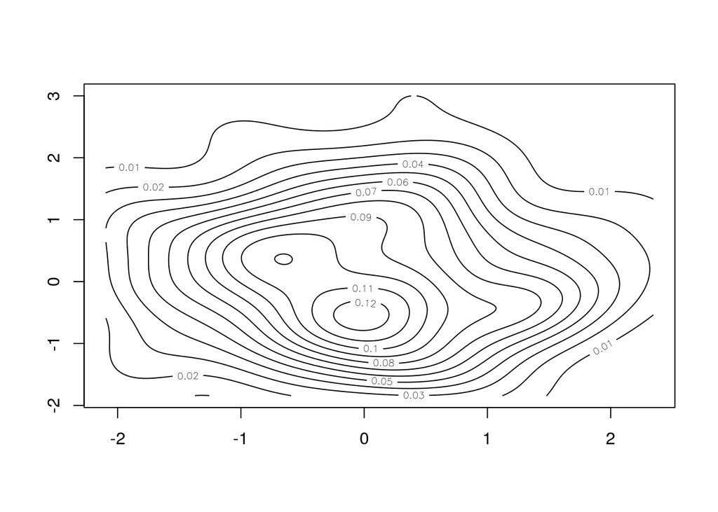

```r
# sample from a 2D distribution
library(mvtnorm)
N = 100
xy <- rmvnorm(n=N, mean=c(0,0), sigma=diag(2))

library(MASS)
xy_density <- kde2d(xy[,1], xy[,2], n=1000)

# image(xy_density)
contour(xy_density)
```

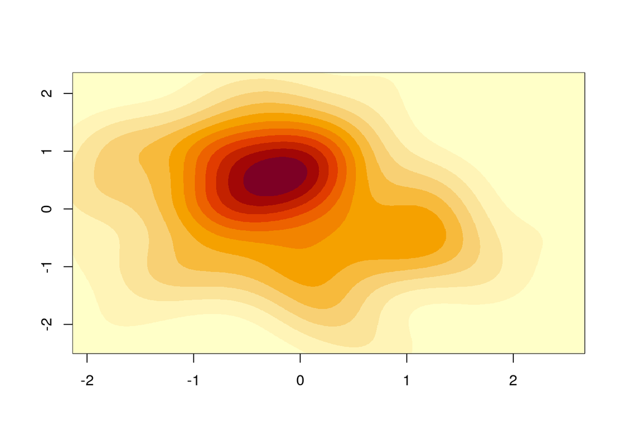

```r
# sample 2D (function)
library(mvtnorm)
library(MASS)

gauss2D <- function(N=100, mu=c(0,0), sigma=diag(2), grid=1000) {
  xy <- rmvnorm(n=N, mean=c(0,0), sigma=sigma)
  xy_density <- kde2d(xy[,1], xy[,2], n=grid)
  return(xy_density)
}

# gauss2D(N=100) %>% contour()
gauss2D(N=100) %>% image(useRaster = T)
```

### GRF

The above methods are all massive univariate, which assume that we are effectively doing with **matrices**. One other possibility is to model the average (mean/median) histogram as a [Gaussian Random Field](https://imaging.mrc-cbu.cam.ac.uk/imaging/PrinciplesRandomFields). This would allow to leverage on one of the oldest MCP methods in neuroimaging.

```r
# grf from geoR
library(geoR)
field <- grf(100^2, grid = "reg", cov.pars=c(1,1))
```

```
## grf: generating grid  100  *  100  with  10000  points
## grf: process with  1  covariance structure(s)
## grf: nugget effect is: tausq= 0
## grf: covariance model 1 is: exponential(sigmasq=1, phi=1)
## grf: simulation using the function GaussRF from package RandomFields
## grf: End of simulation procedure. Number of realizations: 1
```

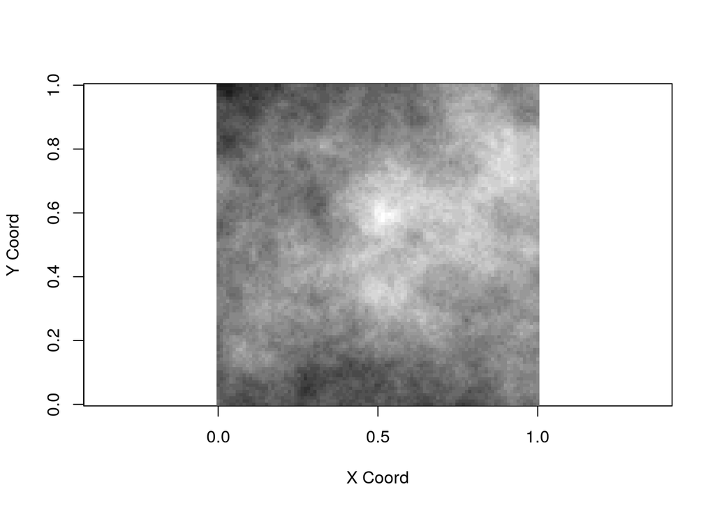

```r
# contour(field)
image(field, col=gray(seq(1, .1, l=30)))
```